# 第10章 顧客の管理

更新：2026-05-13

## データ

#### RFM.txt

```r
# RFM <- read.table("dataset/RFM.txt", header = T, sep = ",")
RFM <- read.csv("dataset/RFM.txt", header = T)
```

[output not shown]

## 4.1 RFM 分析

### 顧客のランク付け

#### 方法1（carパッケージ）

```r
library(car)
R_Rank <- Recode(RFM$R,
                 '0:30="R_Rank5";
                  31:60="R_Rank4";
                  61:90="R_Rank3";
                  91:180="R_Rank2";
                  else="R_Rank1"',
                 as.factor = TRUE)

F_Rank <- Recode(RFM$F,
                 '1="F_Rank1";
                  2="F_Rank2";
                  3:9="F_Rank3";
                  10:29="F_Rank4";
                  else="F_Rank5"',
                 as.factor = TRUE)

M_Rank <- Recode(RFM$M,
                 '0:49999="M_Rank1";
                  50000:99999="M_Rank2";
                  100000:299999="M_Rank3";
                  300000:499999="M_Rank4";
                  else="M_Rank5"',
                 as.factor = TRUE)

# データセットへの追加
RFM <- cbind(RFM, R_Rank, F_Rank, M_Rank)
head(RFM)
```

|  | Customer | M | F | R | DM | R_Rank | F_Rank | M_Rank |
| --- | --- | --- | --- | --- | --- | --- | --- | --- |
| 1 | 1 | 311349 | 6 | 6 | yes | R_Rank5 | F_Rank3 | M_Rank4 |
| 2 | 2 | 509794 | 4 | 28 | yes | R_Rank5 | F_Rank3 | M_Rank5 |
| 3 | 3 | 176331 | 15 | 51 | yes | R_Rank4 | F_Rank4 | M_Rank3 |
| 4 | 4 | 402413 | 30 | 33 | yes | R_Rank4 | F_Rank5 | M_Rank4 |
| 5 | 5 | 16689 | 12 | 4 | no | R_Rank5 | F_Rank4 | M_Rank1 |
| 6 | 6 | 263978 | 4 | 126 | no | R_Rank2 | F_Rank3 | M_Rank3 |

#### 方法2（dplyrパッケージ）

```r
library(dplyr)

RFM <- RFM %>%
  mutate(
    # Recency
    R_Rank = case_when(
      R > 180 ~ "R_Rank1",
      R > 90 & R <= 180 ~ "R_Rank2",
      R > 60 & R <= 90 ~ "R_Rank3",
      R > 30 & R <= 60 ~ "R_Rank4",
      R <= 30 ~ "R_Rank5") %>% as.factor(),
    # Frequency
    F_Rank = case_when(
      F == 1 ~ "F_Rank1",
      F == 2 ~ "F_Rank2",
      F >= 3 & F < 10 ~ "F_Rank3",
      F >= 10 & F < 30 ~ "F_Rank4",
      F >= 30 ~ "F_Rank5") %>% as.factor(),
    # Monetary
    M_Rank = case_when(
      M < 50000 ~ "M_Rank1",
      M >= 50000 & M < 100000 ~ "M_Rank2",
      M >= 100000 & M < 300000 ~ "M_Rank3",
      M >= 300000 & M < 500000 ~ "M_Rank4",
      M >= 500000  ~ "M_Rank5") %>% as.factor()
  )

head(RFM)
```

|  | Customer | M | F | R | DM | R_Rank | F_Rank | M_Rank |
| --- | --- | --- | --- | --- | --- | --- | --- | --- |
| 1 | 1 | 311349 | 6 | 6 | yes | R_Rank5 | F_Rank3 | M_Rank4 |
| 2 | 2 | 509794 | 4 | 28 | yes | R_Rank5 | F_Rank3 | M_Rank5 |
| 3 | 3 | 176331 | 15 | 51 | yes | R_Rank4 | F_Rank4 | M_Rank3 |
| 4 | 4 | 402413 | 30 | 33 | yes | R_Rank4 | F_Rank5 | M_Rank4 |
| 5 | 5 | 16689 | 12 | 4 | no | R_Rank5 | F_Rank4 | M_Rank1 |
| 6 | 6 | 263978 | 4 | 126 | no | R_Rank2 | F_Rank3 | M_Rank3 |

### 箱ひげ図

```r
# 累積購買金額 × R_Rank（図10.7）
boxplot(M ~ R_Rank, data = RFM)

# 累積購買回数 × R_Rank（図10.8）
boxplot(F ~ R_Rank, data = RFM)
```

**`boxplot(formula, data)`：箱ひげ図の作成**

- **`formula`**：目的変数（縦軸）・グループ（横軸）の指定
  - 「目的変数 ~ グループを表す変数」のように，`~` の左側に目的変数，右側にグループを表す変数を記述する
- **`data`**：データの指定

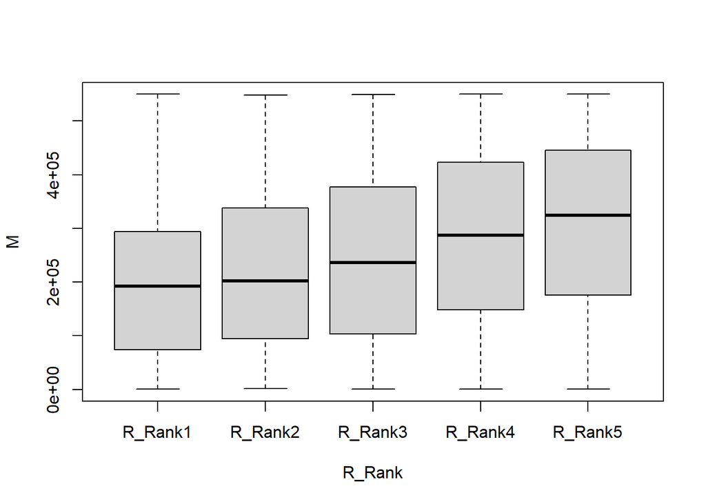

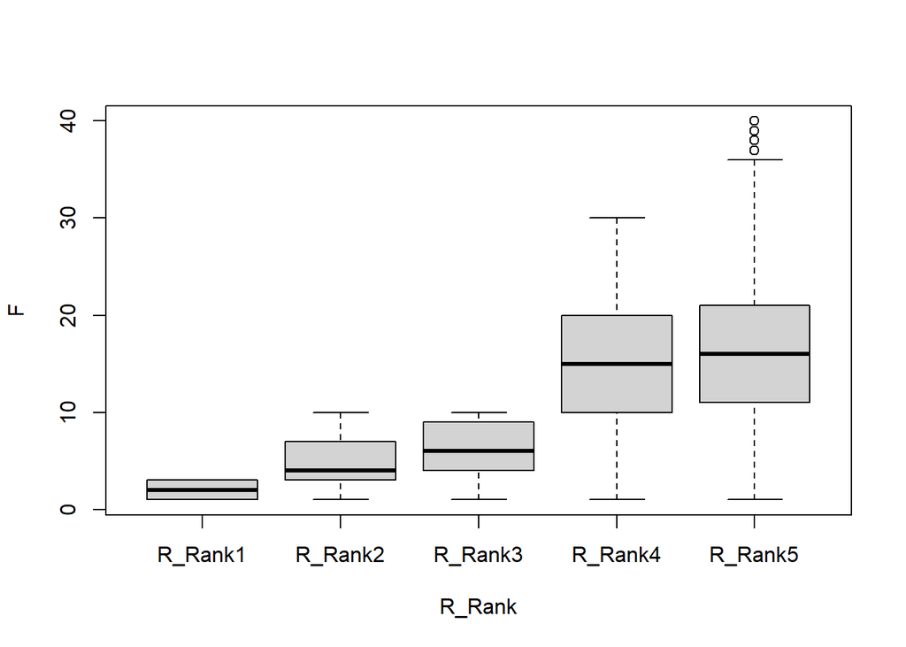

### 分散分析

```r
# 一元配置分散分析
aov_M <- aov(M ~ R_Rank, data = RFM)
summary(aov_M)
```

```
##               Df    Sum Sq   Mean Sq F value Pr(>F)
## R_Rank         4 2.054e+12 5.134e+11   20.78 <2e-16 ***
## Residuals   1995 4.929e+13 2.471e+10
## ---
## Signif. codes:  0 '***' 0.001 '**' 0.01 '*' 0.05 '.' 0.1 ' ' 1
```

**`aov(formula, data)`：分散分析**

- **`formula`**：目的変数と説明変数（要因と水準）の指定
  - 「目的変数 ~ 説明変数」のように，`~` の左側に目的変数，右側に説明変数を記述する
  - 教科書の例では，目的変数は累積購買金額（M），説明変数はRのランク（R_Rank）
- **`data`**：データの指定

```r
# 多重比較
library(multcomp)
glht_M <- glht(aov_M, linfct = mcp(R_Rank = "Tukey"))
summary(glht_M)
```

```
##
##   Simultaneous Tests for General Linear Hypotheses
##
## Multiple Comparisons of Means: Tukey Contrasts
##
##
## Fit: aov(formula = M ~ R_Rank, data = RFM)
##
## Linear Hypotheses:
##                        Estimate Std. Error t value Pr(>|t|)
## R_Rank2 - R_Rank1 == 0    15128      20996   0.721   0.9471
## R_Rank3 - R_Rank1 == 0    37330      22916   1.629   0.4552
## R_Rank4 - R_Rank1 == 0    72034      20149   3.575   0.0029 **
## R_Rank5 - R_Rank1 == 0    96634      20024   4.826   <0.001 ***
## R_Rank3 - R_Rank2 == 0    22202      15113   1.469   0.5599
## R_Rank4 - R_Rank2 == 0    56906      10452   5.444   <0.001 ***
## R_Rank5 - R_Rank2 == 0    81506      10208   7.984   <0.001 ***
## R_Rank4 - R_Rank3 == 0    34704      13914   2.494   0.0830 .
## R_Rank5 - R_Rank3 == 0    59305      13731   4.319   <0.001 ***
## R_Rank5 - R_Rank4 == 0    24601       8330   2.953   0.0233 *
## ---
## Signif. codes:  0 '***' 0.001 '**' 0.01 '*' 0.05 '.' 0.1 ' ' 1
## (Adjusted p values reported -- single-step method)
```

**`glht(model, linfct)`：多重比較**

- **`model`**：分散分析の出力
- **`linfct`**：仮説の指定
  - 多重比較の場合は `mcp`
  - `R_Rank = "Tukey"` でRランクの全てのペアで比較

## 4.2 ロジスティクス回帰

```r
RFM$DM <- as.factor(RFM$DM)   # DMへの反応(yes, no)を factor 型へ変換
# ロジスティクス回帰 (glm) の目的変数は，因子(factor)型または，1 or 0 (yes = 1, no = 0) にする必要がある

result <- glm(DM ~ log(M) + log(F) + log(R), family = "binomial", data = RFM)
summary(result)
```

```
##
## Call:
## glm(formula = DM ~ log(M) + log(F) + log(R), family = "binomial",
##     data = RFM)
##
## Coefficients:
##              Estimate Std. Error z value Pr(>|z|)
## (Intercept) -11.94177    1.05258 -11.345  < 2e-16 ***
## log(M)        0.79688    0.08450   9.431  < 2e-16 ***
## log(F)        1.29098    0.09949  12.977  < 2e-16 ***
## log(R)       -0.47586    0.06170  -7.712 1.24e-14 ***
## ---
## Signif. codes:  0 '***' 0.001 '**' 0.01 '*' 0.05 '.' 0.1 ' ' 1
##
## (Dispersion parameter for binomial family taken to be 1)
##
##     Null deviance: 2614.8  on 1999  degrees of freedom
## Residual deviance: 1873.8  on 1996  degrees of freedom
## AIC: 1881.8
##
## Number of Fisher Scoring iterations: 5
```

**`glm(fomula, family, data)`：一般化線型モデルの推定**

- **`fomula`**：目的変数と説明変数の指定
- **`family`**：データが従う確率分布の指定
  - ロジスティクス回帰の場合は `"binomial"` を指定
  - `family` を変更すれば，ポアソン回帰などのその他の一般化線型モデルも推定可能
- **`data`**：データの指定